# Veridato-CTI Quick Guide

## Copyright Notice

### Copyright © 2016, Bitnine Inc. All Rights Reserved.

#### PostgreSQL is Copyright © 1996-2018 by the PostgreSQL Global Development Group.

#### Postgres95 is Copyright © 1994-5 by the Regents of the University of California.

#### AgensGraph and Veridato-CTI is Copyright © 2016 by Bitnine Inc.

#### Permission to use, copy, modify, and distribute this software and its documentation for any purpose, without fee, and without a written agreement is hereby granted, provided that the above copyright notice and this paragraph and the following two paragraphs appear in all copies.

#### IN NO EVENT SHALL THE UNIVERSITY OF CALIFORNIA BE LIABLE TO ANY PARTY FOR DIRECT, INDIRECT, SPECIAL, INCIDENTAL, OR CONSEQUENTIAL DAMAGES, INCLUDING LOST PROFITS, ARISING OUT OF THE USE OF THIS SOFTWARE AND ITS DOCUMENTATION, EVEN IF THE UNIVERSITY OF CALIFORNIA HAS BEEN ADVISED OF THE POSSIBILITY OF SUCH DAMAGE.

#### THE UNIVERSITY OF CALIFORNIA SPECIFICALLY DISCLAIMS ANY WARRANTIES, INCLUDING, BUT NOT LIMITED TO, THE IMPLIED WARRANTIES OF MERCHANTABILITY AND FITNESS FOR A PARTICULAR PURPOSE. THE SOFTWARE PROVIDED HEREUNDER IS ON AN ”AS-IS” BASIS, AND THE UNIVERSITY OF CALIFORNIA HAS NO OBLIGATIONS TO PROVIDE MAINTENANCE, SUPPORT, UPDATES, ENHANCEMENTS, OR MODIFICATIONS.

### Trademarks

#### AgensGraph® is a registered trademark of Bitnine Global Inc. Other products, titles or services may be registered trademarks of their respective companies.

#### Veridato-CTI® is a registered trademark of Bitnine Global Inc. Other products, titles or services may be registered trademarks of their respective companies.

### Open Source Software Notice

#### Some modules or files of this product are subject to the terms of the following licenses. : OpenSSL, RSA Data Security, Inc., Apache Foundation, Jean-loup Gailly and Mark Adler, Paul Hsieh’s hash.

### Information of technical documentation

#### S/W version : Veridato-CTI v1.0

#### Technical documentation version : v1.0

# Overview

## 문서 정보

### About the Documentation

이 문서는 비트나인의 Veridato-CTI 제품을 소개하고, 제품의 기능 및 설치/사용 방법에 대하여 설명하기 위하여 작성되었습니다. 이 문서 내용 외 제품과 관련된 문의는 비트나인 공식 웹사이트 [Link](https://bitnine.net)을 통하여 확인하여 주시기 바랍니다.

### License

Creative Commons 3.0 License (https://creativecommons.org/licenses/by-sa/3.0/)

## 비트나인 Veridato-CTI 소개

### 제품 개요

Veridato-CTI는 서로 다른 보안 장비에서 나온 로그를 수집하여 저장하고, MITRE Taxii, ThreatCrowd, ThreatMiner, VirusTotal 등 여러 개의 수집 채널에서 위협자원(정보)으로 사용된 IP, 도메인, 이메일, 해시 정보 내 그래프 패턴 또는 연결성을 통해 자원 간의 관계를 찾아내어 직접적인 연관성은 없는 정보지만 패턴을 통해 의미를 발견하여 사용자에게 제공하는 위협 자원 분석 소프트웨어입니다.

Veridato-CTI는 최적의 연관 관계 분석을 위하여 연관 관계를 직접적으로 저장하고 다룰 수 있는 AgensGraph 그래프 데이터베이스를 기반 기술로써 활용합니다.

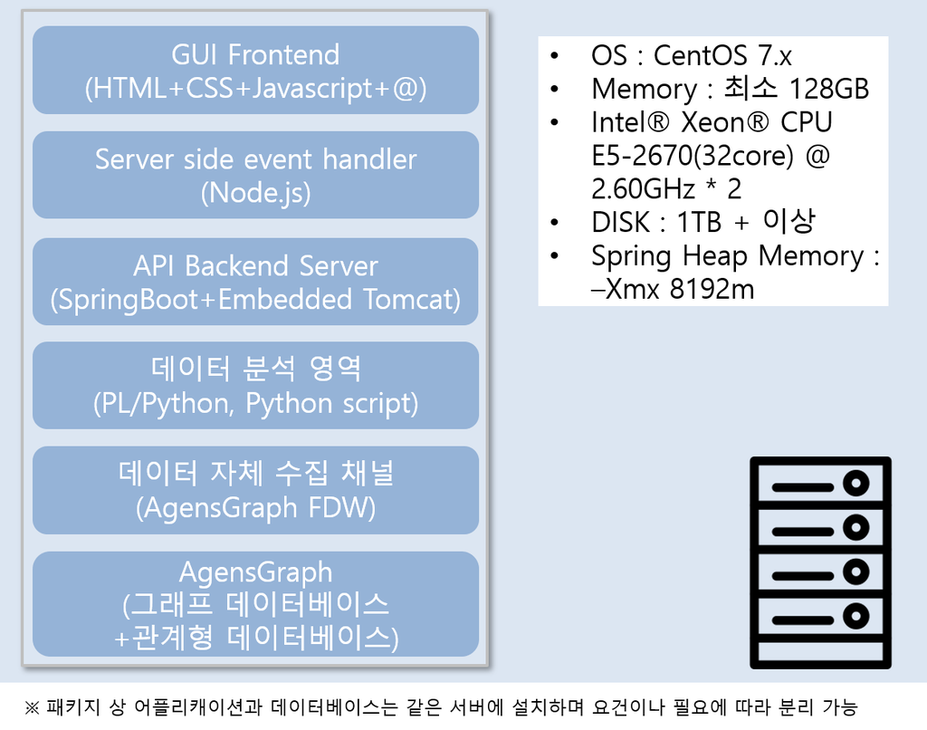

### AgensGraph 그래프 데이터베이스

AgensGraph is a new generation multi-model graph database for the modern complex data environment. AgensGraph is a multi-model database based on PostgreSQL RDBMS, and supports both relational and graph data models at the same time. This enables developers to integrate the legacy relational data model and the flexible graph data model in one database. AgensGraph supports Ansi-SQL and Open Cypher (http://www.opencypher.org). SQL queries and Cypher queries can be integrated into a single query in AgensGraph.

AgensGraph is very robust, fully-featured and ready for enterprise use. It is optimized for handling complex connected graph data and provides plenty of powerful database features essential to the enterprise database environment including ACID transactions, multi-version concurrency control, stored procedure, triggers, constraints, sophisticated monitoring and a flexible data model (JSON). Moreover, AgensGraph leverages the rich eco-systems of PostgreSQL and can be extended with many outstanding external modules, like PostGIS.

## 주요 기능

- 동일 또는 유사 사이버 위협 정보 검색
- 사이버 위협 정보 및 연관 위협 정보 시각화
- 특정 사이버 위협 정보 및 관련 세부 정보 조회
- 특정 사이버 위협 정보 화이트리스트/블랙리스트 등록
- 특정 사이버 위협 정보 전체 공격 자원 사용 패턴 조회
- 사이버 위협 정보 그래프 패턴 내 핵심 위협 자원 분석
- 사이버 위협 정보 그래프 패턴 내 그룹 인식 및 분류
- 특정 사이버 위협 정보 관련 유사 위협 정보 시각화
- 위협 정보 그래프 유사도 실시간 분석 및 공유
- 모티프 추출(Motif Extraction) 기반 위협 정보 변형에 대한 패턴 인식 공유

# Installation

AgensGraph runs on Linux and Windows. There are two methods available to install AgensGraph: downloading the binary package or compiling the package from source code.

## 설치 환경

Veridato-CTI 설치를 위하여 아래와 같은 환경 구성을 보유 또는 구성하여야 합니다.

### 운영체제

- Redhat 계열의 64bit 리눅스
  - CentOS 7.X
  - RedHat Enterprise Linux 7

### 하드웨어

- CPU
  - 32 Core 이상
- Memory
  - 128GB 이상
- Harddisk 공간
  - 1TB 이상

### 기타 환경

- Python 2.7 버전
  - Python 3 버전 사용 불가
- Java 1.8 버전
  - Lambda 방식의 코드가 구현되어 있어 1.8 버전 이상에서만 지원
- Node.js 버전
  - Node 8.X 이상 버전 권장
  - npm 6.x 이상 버전 권장

## Download

홈페이지를 통해 설치 바이너리 형태로 제공될 예정

## Installation

1. TAR 파일 해제

```
tar xvzf veridato-ctias-v1.0.tar.gz
```

2. 환경변수 설정

```
아래 내용을 .bashrc 또는 .bash_profile에 추가\n
export VCHOME=$HOME/veridato-ctias #Veridato Home
export AGHOME=$VCHOME/agraph #Agensgraph
export AGDATA=$VCHOME/db_cluster
export PATH=$VCHOME:$AGHOME/bin:$PATH
export LD_LIBRARY_PATH=$AGHOME/lib:$LD_LIBRARY_PATH
```

3. 환경변수 적용

```
source .bash_profile 또는 source .bashrc
```

4. 서버 기동

```
ctias-start
```

5. 서버 중지

```
ctias-stop
```

## Post-Installation

1. logs 폴더 내 ctias-java.log 확인

```
view logs/ctias-java.log
```

2. logs 폴더 내 ctias-node.log 확인

```
view logs/ctias-node.log
```

## 고객 지원

- Tel. 070-4800-3517
- Email. agens@bitnine.net

## 유지 보수

라이센스 정책에 따라 상이함

# Configuration

Veridato-CTI는 디렉토리 내 veridato-config.yml 설정 파일 수정을 통하여 서버 구동 및 동작 모듈을 수정 변경할 수 있다.

## 설정 변수 및 설명

| 번호 | 설정 변수 | 변수 설명 |
| --- | --- | --- |
| 1 | spring.datasource.url | agensgraph jdbc 커넥션 url 정보 |
| 2 | spring.datasource.host | JDBC 호스트 정보 |
| 3 | spring.datasource.port | JDBC connection port 정보 |
| 4 | spring.datasource.database | Database 이름 |
| 5 | spring.datasource.username | Database 유저 이름 |
| 6 | spring.datasource.password | 유저 암호 |
| 7 | spring.datasource.graph-path | 그래프 패스 |
| 8 | spring.datasource.driver-class-name | JDBC 드라이버 이름 |
| 9 | spring.datasource.mongofdw | 수집시스템 MongoDB FDW 이름 |
| 10 | spring.datasource.mongoserver | MongoDB FDW 서버 이름 |
| 11 | spring.data.mongodb.host | 수집시스템 MongoDB 호스트 정보 |
| 12 | spring.data.mongodb.port | 수집시스템 MongoDB 포트 |
| 13 | spring.data.mongodb.database | 수집시스템 MongoDB collection 이름 |
| 14 | query.path | CTIAS 쿼리 모음 파일 경로 |
| 15 | server.tomcat.max-threads | 톰캣 MAX thread 개수 |
| 16 | server.tomcat.accesslog.enabled | 톰캣 로그 허용 플래그 |
| 17 | server.port | 서버 포트 |
| 18 | veridato.cpool.setMinimumIdle | 시스템 커넥션풀 최소 수 |
| 19 | veridato.cpool.setMaximumPoolSize | 시스템 커넥션풀 최대 수 |
| 20 | management.context-path | 모니터링 API 주소 |
| 21 | management.security.enabled | 모니터링 탐지 플래그 허용여부 |
| 22 | endpoints.cors.allowed-origins | Cross origin resources sharing 요청 페이지 정보 |
| 23 | endpoints.cors.allowed-methods | Cross origin resources sharing 요청 메소드 정보 |
| 24 | endpoints.cors.allowed-headers | Cross origin resources sharing 요청 허용 헤더 정보 |
| 25 | endpoints.cors.allow-credentials | Cross origin resources sharing 자격증명 지원여부 |
| 26 | endpoints.cors.max-age | Cross origin resources sharing 요청 결과 저장 시간 |
| 27 | security.basic.enabled | 시큐어 코딩용 |
| 28 | cti.fdw.multicorn.basic.enabled | FDW 스크립트 수행 스캐쥴러 제어 플래그 |
| 29 | ctias.security.enabled | 시큐어 코딩용(Jar 말때 문제가 있어서 false) |
| 30 | ctias.attackpattern.list | 공격패턴 리스트 순서 |
| 31 | mongodb.basic.enabled | MongoDB ETL 수행 스캐쥴러 제어기 |
| 32 | net.bitnine.veridato.scheduling.enabled | 프로젝트 기본 분석 스캐쥴러 제어기 |
| 33 | similar.types | 유사도 분석 타입 종류 |

# Visual Tour

## 각 화면 설명

### 메인 검색 화면

[figure not shown]

#### 화면 설명

- 알고 있는 IP, 도메인, 이메일 등의 정보를 검색하여 서로 연관이 있는 정보들을 찾습니다.
- 검색 창에 정보를 입력하면 Veridato-CTI 제품에서 관리되는 유사한 정보들을 리스트로 제공합니다.
- 환경설정을 통하여 관리되는 위협정보의 클러스터 현황, 블랙리스트 관리, 위협패턴 등록이 가능합니다.

#### 각 부분의 이름 및 기능

1. 검색창
   - 검색하고자 하는 값과 연관된 정보에 대해 탐색을 진행합니다.
2. 검색어 추천리스트
   - 입력된 검색어와 제품에서 관리되는 위협정보를 비교하여 유사한 정보를 제공합니다.

### 그래프 탐색 화면

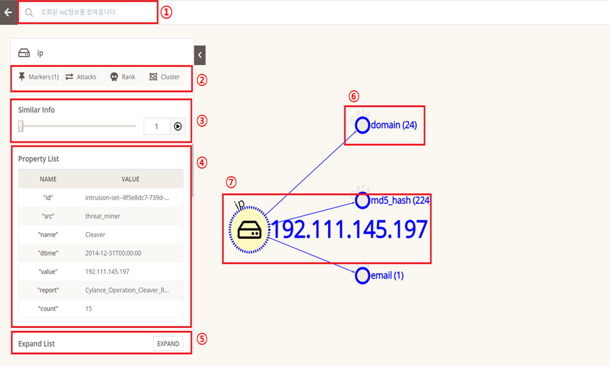

#### 화면 설명

- 검색한 정보와 일치하거나 가장 유사한 정보를 노드로 표현합니다.
- 조회된 노드의 확장을 통해 관련 정보를 탐색 과정을 진행합니다.
- IoC(Indicator of Compromise) 정보 중에서 같은 공격그룹(name)에 포함되지 않은 정보들과 연관 관계(엣지)가 있다면 복수 개의 공격그룹에서 공통으로 사용한 정보임을 확인할 수 있습니다.
- 새로 검색한 정보나 Veridato-CTI에 입력된 정보 중 위협정보로 판별되진 않았으나 유사도 검색을 통해 관련이 있는 노드가 조회된다면, 새로운 정보는 위협자원으로 판별할 수 있습니다.

#### 각 부분의 이름 및 기능

1. 결과 내 검색
   - 탐색 된 위협정보 내 입력한 값과 일치하는 위협정보를 표시합니다.
2. 부가기능
   - Marker: 선택한 위협정보에 대하여 블랙리스트/화이트리스트로 등록
   - Attacks: 선택한 위협정보에서 다른 공격그룹과 연결된 시점까지 확장
   - Rank: 선택한 위협정보와 관련된 가장 높은 랭크(위협도)를 분석 및 표출
   - Cluster: 선택한 위협정보와 화면상에서 같은 클러스터에 속하는 정보 정렬 및 색상 표시
3. 유사범위 조절
   - 유사하다고 판별되는 연관 관계(다홍색 점선 표시) 중 유사도 가중치 이상의 연관 관계로 연결된 정보를 표시합니다.
4. 상세 속성 정보
   - 선택한 위협정보가 가지고 있는 속성정보를 보여줍니다.
5. 확장 가능 정보 리스트
   - 선택한 위협정보와 연관 관계가 존재하는 노드 정보를 리스트로 보여줍니다. 리스트를 선택하여 탐색 범위를 확장합니다.
6. 연관정보 미리 보기
   - 선택된 노드와 연관이 있는 정보의 타입과 해당 건수를 미리 보여주는 기능입니다.
7. 검색 조회 결과
   - 검색창에서 입력한 값을 Veridato-CTI 제품 내에 관리되는 정보 중 해당하는 값을 조회하여 보여주거나 입력한 값 자체를 보여 줍니다.

## 주요 기능 설명

### 정보검색

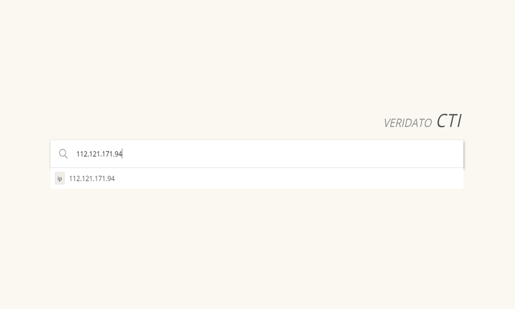

- 검색 박스에 값을 입력하게 되면 입력한 값과 가장 유사한 리스트가 순서대로 나타납니다.
- Enter 버튼을 누르면 입력한 값 또는 그 값과 가장 유사한 값을 기준으로 탐지가 진행됩니다.
- 만약 Veridato-CTI에서 관리되지 않는 정보이면, 입력값 그대로 탐지가 진행되며 입력한 값과 유사하다고 판단되는 위협정보와의 관계 그래프로 표현됩니다.

### 마우스 클릭 이벤트

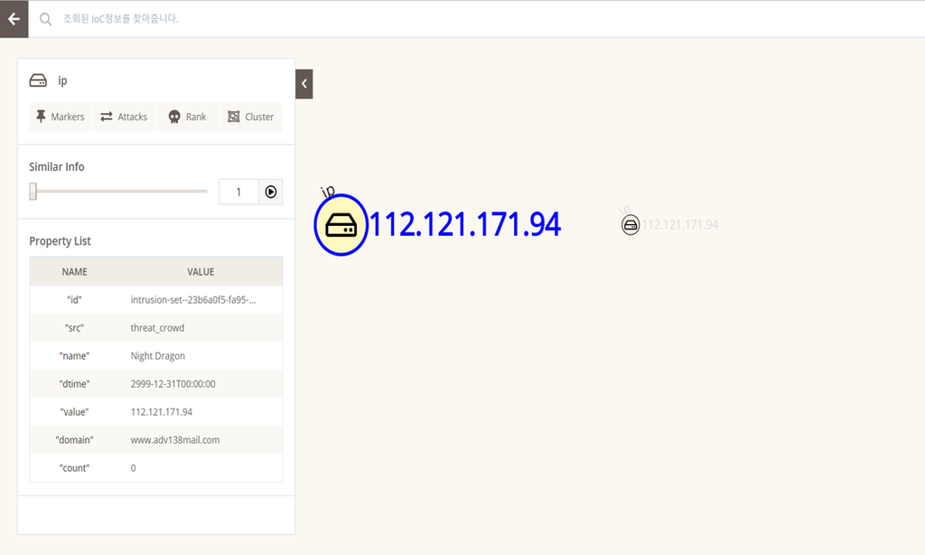

- 위협정보를 클릭하면 화면 왼쪽에 위협정보의 상세속성을 확인하거나 부가기능을 수행할 수 있는 창이 나타납니다.

### 마우스 호버 이벤트

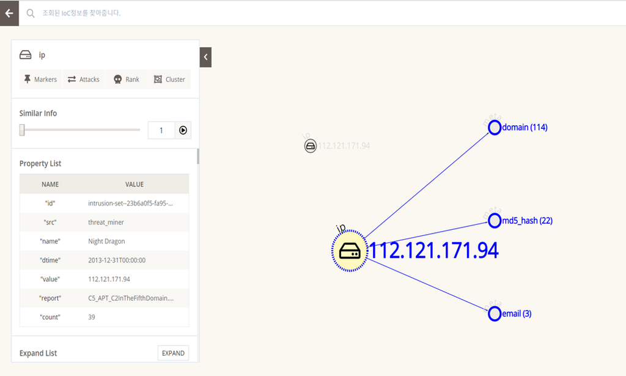

### 마우스 더블클릭 이벤트

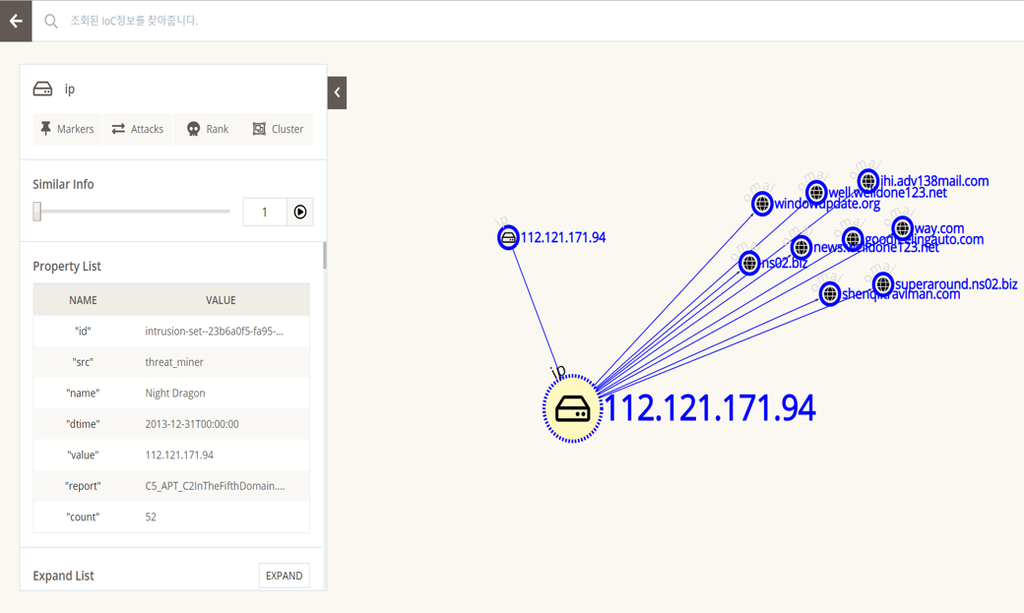

- 위협정보를 더블 클릭하게 되면 한 단계까지 연관 관계가 있는 패턴을 조회하고 그래프 탐색을 위한 확장을 진행합니다.
- 탐색 된 정보 중 연관 관계가 없는 것처럼 보였던 정보들도 탐색을 통해 실제로 관계가 존재한다면 정보 간의 연관 관계를 표시하여 줍니다.
- 확장 가능한 위협정보가 10건 이상이면, 10건만 위협정보를 그래프로 표현합니다.
- 위협정보가 10건 미만이면 전체 탐색 결과를 그래프로 표현합니다.

### 마킹 기능

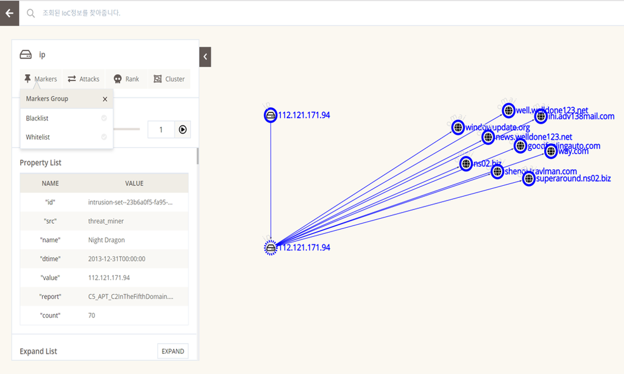

- 화면에 나타난 위협정보를 클릭하여 화이트리스트 또는 블랙리스트로 등록합니다.
- 왼쪽 속성창 상단에 Markers 버튼을 클릭하면 화이트리스트 또는 블랙리스트로 등록 가능한 리스트가 나타납니다.
- 주로 위협정보의 접근성이 높은 정보나 Rank 알고리즘의 결과로 탐색 되는 위협정보를 블랙리스트로 관리합니다.
- 탐색 된 정보 중 불필요한 정보이거나 위협정보가 아닌 정보로 판별되면 화이트 리스트로 관리합니다.

### 공격 탐색

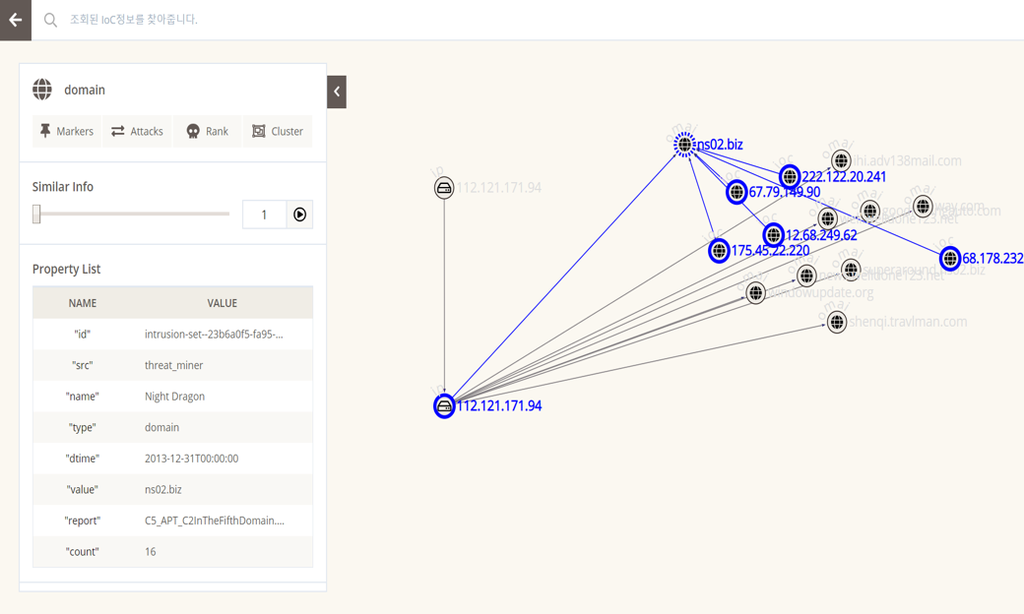

- 탐색 된 위협정보를 클릭합니다.
- 왼쪽 속성 창에서 Attacks 버튼을 클릭합니다.
- Attacks 버튼을 클릭하게 되면, 위협정보와 다른 기종에서 수집된 로그 정보 또는 자체 수집 채널 중 여러 수집 채널에서 조회된 위협정보의 전체 연관 관계를 조회합니다.

### 랭크 알고리즘 수행

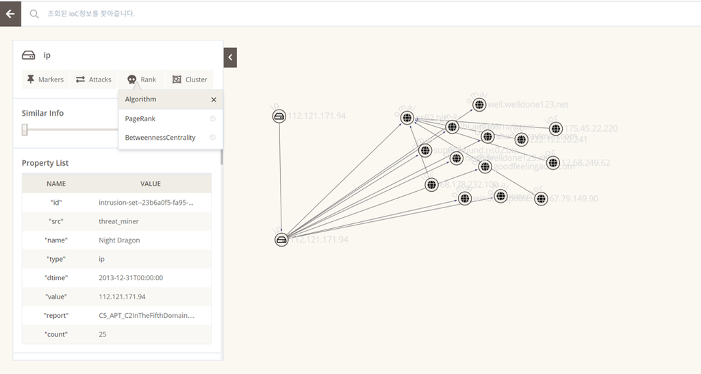

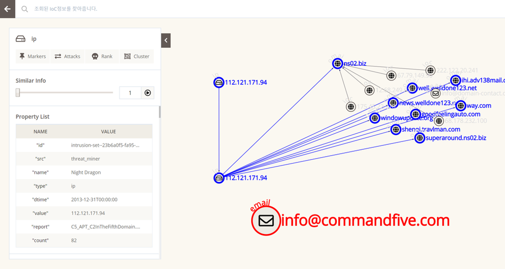

- 왼쪽 속성 창에서 Rank 버튼을 클릭하면 PageRank, Betweenness Centrality 두 가지의 Rank 알고리즘을 선택하여 원하는 알고리즘을 수행할 수 있습니다.
- 알고리즘은 선택한 위협정보와 5단계 이하의 범위 중 가장 Rank가 높은 정보를 찾습니다.
- Rank 알고리즘을 수행하면 화면에 그래프로 존재하는 위협정보가 Rank가 높은 경우 글자와 선이 빨간색으로 변합니다.
- 화면에 Rank가 가장 높은 정보가 없다면 탐색하여 그래프로 표현합니다.

### 클러스터 조회

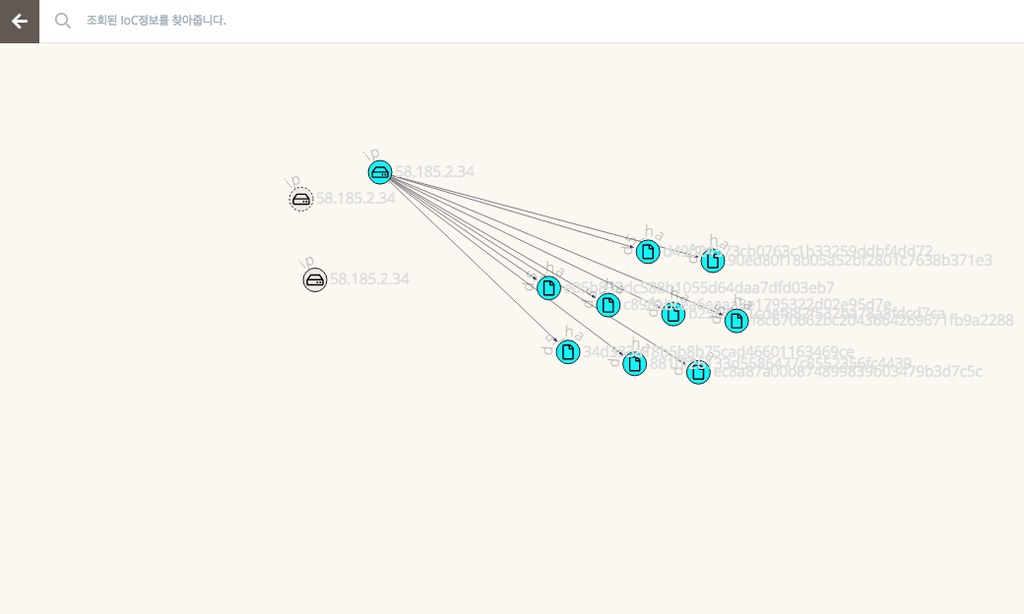

- 클러스터 버튼을 누르게 되면 조회된 위협정보들이 Veridato-CTI에서 분류된 공격 클러스터 집단 중 같은 집단에 속하는 정보라면 같은 색으로 채워집니다.
- 서로 다른 클러스터로 분류된 위협정보들 중에서 서로 연관 관계가 존재하는 정보들을 찾기 위해 사용합니다.

### 결과 내 검색

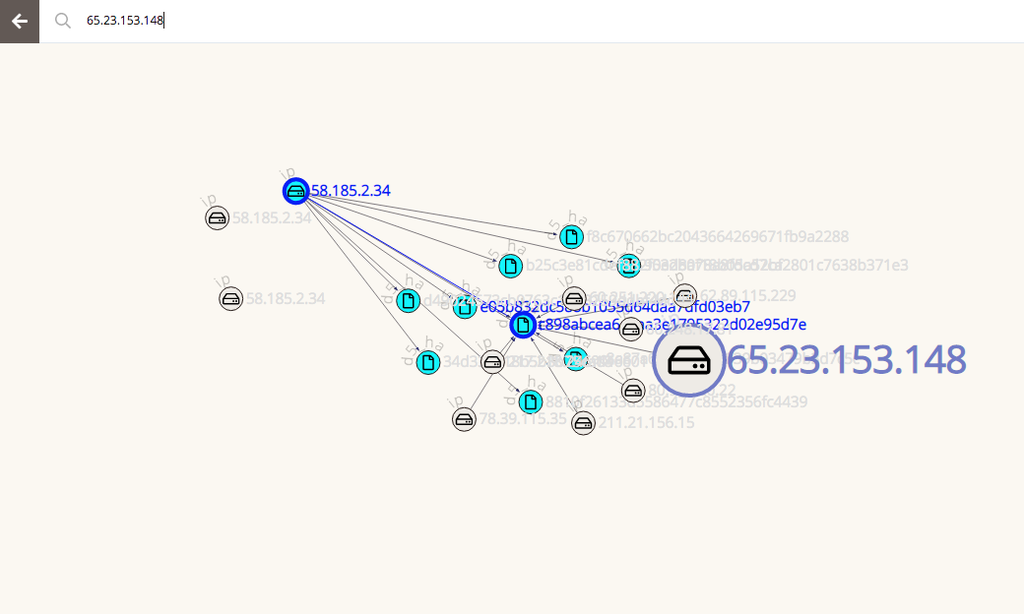

- 상단 검색창에 값을 입력하면 조회된 위협정보 중 값과 일치하는 정보의 그래프 크기와 색상을 변경합니다.
- 결과 내 검색이 수행되면 위협정보에 포커싱이 맞춰서 화면이 이동됩니다.

# Rest APIs

## 공유 API 리스트

[output not shown]

## 사용 예제

#### 시그니처 룰 기반의 패턴을 조회

- 요청 메시지

```
/analysis/context/data?recommend=192.111.145.197&contextVal=(ioc)-[related_to]->(ioc)
```

- 응답 메시지

```
{
    "parameters": {
        "recommend": "192.111.145.197",
        "contextVal": "(ioc)-[related_to]->(ioc)"
    },
    "embedded": [
        {
            "edges": [
                {
                    "label": "related_to",
                    "id": "5.253980",
                    "source": "3.782",
                    "target": "3.8527",
                    "props": "{}"
                }
                ...
```

#### 사용자에게 추천 키워드를 제공

- 요청 메시지

```
/analysis/context/keyword
Accept: application/json, application/hal+json
Content-Type: application/json
{
    "ruleValue":"(ioc)-[ref_to]->(ioc)"
}
```

- 응답 메시지

```
{
    "parameters": {
        "ruleValue": "(ioc)-[ref_to]->(ioc)"
    },
    "embedded": "[{\"keyword\":\"\"},{\"keyword\":\"\\\"82747.ddnsd.at\"},{\"keyword\":\"%2A.166blog.afbjz.com\"},{\"keyword\":\"%2A.aapalamalhari.com\"},{\"keyword\":\"%2A.adobe-center.net\"},{\"keyword\":\"%2A.adv-webhost.com\"},{\"keyword\":\"%2A.afbjz.com\"},{\"keyword\":\"%2A.applesea.net\"},{\…
    "_links": {
        "selfLink": {
            "href": "http://192.168.0.68:8081/analysis/context/keyword"
        }
    }
}
```

#### 사이버 공격 그룹을 조회

- 요청 메시지

```
/api/report/cluster?page=1&rows=10
```

- 응답 메시지

```
{
    "parameters": {
        "page": "1",
        "rows": "10"
    },
    "embedded": [
        {
            "created_time": 1564358540010,
            "cluster_id": 1,
            "members": "{3.218376,3.251601,3.252692,3.251786,3.216979,3.258547,3.296851,3.295462}"
        },
        {
            "created_time": 1564358540010,
            "cluster_id": 2,
            "members": "{3.203480,3.169176}"
        },
        {
            "created_time": 1564358540010,
            "cluster_id": 3,
            "members": "{3.218374,3.252690,3.251599,3.251784,3.258545,3.295460,3.216977,3.296849}"
        },
        ...
```

#### ID 기준 클러스터 정보 조회

- 요청 메시지

```
/api/search/cluster?cluster_id=1
```

- 응답 메시지

```
{
    "parameters": {
        "cluster_id": "1"
    },
    "embedded": [
        {
            "data": {
                "name": "54.178.211.71",
                "id": "3.218376"
            },
            "group": "nodes"
        },
        {
            "data": {
                "name": "APT18",
                "id": "APT18"
            },
            "group": "nodes"
        },
        ...
```

#### 위협정보를 기준으로 클러스터 조회

- 요청 메시지

```
/api/search/cluster/graph?value=192.111.145.197
```

- 응답 메시지

```
{
    "parameters": {
        "value": "192.111.145.197"
    },
    "embedded": [
        {
            "data": {
                "name": "192.111.145.197",
                "id": "3.351061"
            },
            "group": "nodes"
        },
        {
            "data": {
                "name": "192.111.145.197",
                "id": "3.348711"
            },
            "group": "nodes"
        },
        ...
```

#### 위협정보가 포함된 클러스터 그래프 조회

- 요청 메시지

```
/api/search/cluster/details?value=192.111.145.197
```

- 응답 메시지

```
{
    "parameters": {
        "value": "192.111.145.197"
    },
    "embedded": [],
    "_links": {
        "selfLink": {
            "href": "http://192.168.0.68:8081/api/search/cluster/details?value=192.111.145.197"
        }
    }
}
```

#### Scope에 따른 전체 그래프 조회

- 요청 메시지

```
/api/search/cti/info?distance=1&scope=1&label=ioc&value=192.111.145.197
```

- 응답 메시지

```
{
    "parameters": {
        "distance": "1",
        "scope": "1",
        "label": "ioc",
        "value": "192.111.145.197"
    },
    "embedded": [
        {
            "result": {
                "result": [
                    {
                        "path": {
                            "type": "graphpath",
                            "value": "[ioc[3.782]{\"id\": \"intrusion-set--8f5e8dc7-739d-4f5e-a8a1-a66e004d7063\", \"src\": \"threat_miner\", \"name\": \"Cleaver\", \"type\": \"ip\", \"dtime\": \"2014-12-31T00:00:00\", \"value\": \"192.111.145.197\", \"report\": \"Cylance_Operation_Cleaver_Report.pd…
                        }
                    },
                    ...
```

#### 그래프 쿼리를 사용하여 정보 조회

- 요청 메시지

```
/api/search/cypher?query=MATCH (a) RETURN a LIMIT 1
```

- 응답 메시지

```
{
    "parameters": {
        "query": "MATCH (a) RETURN a LIMIT 1"
    },
    "embedded": "[{\"result\":[{\"a\":ioc[3.347930]{\"src\":\"threat_miner\",\"dtime\":\"2016-12-31T00:00:00\",\"name\":\"Axiom\",\"report\":\"Operation-Blockbuster-Report.pdf\",\"id\":\"intrusion-set--a0cb9370-e39b-44d5-9f50-ef78e412b973\",\"type\":\"ip\",\"value\":\"4.3.3.5\"}}]}]",
    "_links": {
        "selfLink": {
            "href": "http://192.168.0.68:8081/api/search/cypher?query=MATCH%20(a)%20RETURN%20a%20LIMIT%201"
        }
    }
}
```

#### 위협정보의 그래프 노드 정보 조회

- 요청 메시지

```
/api/search/cti/node?label=ioc&value=192.111.145.197
```

- 응답 메시지

```
{
    "parameters": {
        "label": "ioc",
        "value": "192.111.145.197"
    },
    "embedded": "[]",
    "_links": {
        "selfLink": {
            "href": "http://192.168.0.68:8081/api/search/cti/node?label=ioc&value=192.111.145.197"
        }
    }
}
```

#### 위협정보 기준 그래프 패턴을 조회

- 요청 메시지

```
/api/search/cti/node/pattern?pattern=(a:ioc)&value=192.111.145.197
```

- 응답 메시지

```
{
    "parameters": {
        "pattern": "(a:ioc)",
        "value": "192.111.145.197"
    },
    "embedded": "[{\"result\":[{\"a\":ioc[3.351061]{\"src\":\"threat_miner\",\"dtime\":\"2014-12-31T00:00:00\",\"name\":\"Cleaver\",\"report\":\"Cylance_Operation_Cleaver_Report.pdf\",\"id\":\"intrusion-set--8f5e8dc7-739d-4f5e-a8a1-a66e004d7063\",\"type\":\"ip\",\"value\":\"192.111.145.197\"},\"path…
    "_links": {
        "selfLink": {
            "href": "http://192.168.0.68:8081/api/search/cti/node/pattern?pattern=(a:ioc)&value=192.111.145.197"
        }
    }
}
```

#### CTIAS 내 위협정보 간 유사도 분석

- 요청 메시지

```
/api/search/cti/find?label=ioc&value=192.111.145.197
```

- 응답 메시지

```
{
    "parameters": {
        "label": "ioc",
        "value": "192.111.145.197"
    },
    "embedded": "[{\"val\":\"192.111.145.197\",\"sim\":1}]",
    "_links": {
        "selfLink": {
            "href": "http://192.168.0.68:8081/api/search/cti/find?label=ioc&value=192.111.145.197"
        }
    }
}
```

#### 위협정보의 그래프 ID를 조회

- 요청 메시지

```
/api/search/cti/find/graphid?label=ioc&value=192.111.145.197
```

- 응답 메시지

```
{
    "parameters": {
        "label": "ioc",
        "value": "192.111.145.197"
    },
    "embedded": [
        {
            "graph_id": {
                "type": "graphid",
                "value": "3.351061",
                "oid": 3,
                "id": 351061
            }
        },
        {
            "graph_id": {
                "type": "graphid",
                "value": "3.348711",
                "oid": 3,
                "id": 348711
            }
        },
        ...
```

#### 그래프ID가 포함된 클러스터 ID를 조회

- 요청 메시지

```
/api/search/cti/find/clusterid?graphid=3.782
```

- 응답 메시지

```
{
    "parameters": {
        "graphid": "3.782"
    },
    "embedded": [
        {
            "cluster_id": 836
        }
    ],
    "_links": {
        "selfLink": {
            "href": "http://192.168.0.68:8081/api/search/cti/find/clusterid?graphid=3.782"
        }
    }
}
```

#### 위협정보를 기준으로 랭크 알고리즘 분석

- 요청 메시지

```
/api/search/cti/rank?algoOption=0&value=192.111.145.197
```

- 응답 메시지

```
{
    "parameters": {
        "algoOption": "0",
        "value": "192.111.145.197"
    },
    "embedded": [
        {
            "rank_value": null,
            "node_value": null,
            "node_id": null
        },
        {
            "rank_value": null,
            "node_value": null,
            "node_id": null
        }
    ],
    "_links": {
        "selfLink": {
            "href": "http://192.168.0.68:8081/api/search/cti/rank?algoOption=0&value=192.111.145.197"
        }
    }
}
```

#### N개의 정보를 기준으로 N:N 유사도 분석

- 요청 메시지

```
/api/search/cti/similarity?label1=ip&value1=211.11.213.22&label2=ip&value2=211.132.25.1
```

- 응답 메시지

```
{
    "parameters": {
        "label1": "ip",
        "value1": "211.11.213.22",
        "label2": "ip",
        "value2": "211.132.25.1"
    },
    "embedded": [
        {
            "result": "0.10",
            "used_formula": "Result = (Value Similarity)*1.0",
            "use_prop_sim": "false",
            "used_method": "IP Similarity"
        }
    ],
    "_links": {
        "selfLink": {
            "href": "http://192.168.0.68:8081/api/search/cti/similarity?label1=ip&value1=211.11.213.22&label2=ip&value2=211.132.25.1"
        }
    }
}
```

#### 클러스터의 엔트로피 추이를 조회

- 요청 메시지

```
/api/search/summary/entropy?cluster_id=1
```

- 응답 메시지

```
{
    "parameters": {
        "cluster_id": "1"
    },
    "embedded": "[]",
    "_links": {
        "selfLink": {
            "href": "http://192.168.0.68:8081/api/search/summary/entropy?cluster_id=1"
        }
    }
}
```

#### 클러스터 내 위협정보의 수를 조회

- 요청 메시지

```
/api/search/summary/size?cluster_id=1
```

- 응답 메시지

```
{
    "parameters": {
        "cluster_id": "1"
    },
    "embedded": "[{\"cluster_size\":8}]",
    "_links": {
        "selfLink": {
            "href": "http://192.168.0.68:8081/api/search/summary/size?cluster_id=1"
        }
    }
}
```

#### 위협정보와 연관된 정보의 종류와 수 조회

- 요청 메시지

```
/api/search/summary/ctitype?value=192.111.145.197
```

- 응답 메시지

```
{
    "parameters": {
        "value": "192.111.145.197"
    },
    "embedded": "[{\"count\":393,\"label\":\"ioc\"}]",
    "_links": {
        "selfLink": {
            "href": "http://192.168.0.68:8081/api/search/summary/ctitype?value=192.111.145.197"
        }
    }
}
```

#### 위협정보 메타그래프 조회

- 요청 메시지

```
/api/report/meta/graph
```

- 응답 메시지

```
{
    "parameters": {},
    "embedded": [
        {
            "data": {
                "name": "ioc",
                "id": "node_3",
                "label": "ioc"
            },
            "style": {
                "background-color": null,
                "text-outline-color": "black",
                "text-outline-width": 2
            },
            "group": "nodes"
        },
        ...
```

#### GUI Result Table 정보를 조회

- 요청 메시지

```
/api/search/result/table?label=ioc&value=192.111.145.197
```

- 응답 메시지

```
{
    "parameters": {
        "label": "ioc",
        "value": "192.111.145.197"
    },
    "embedded": "[{\"label\":\"ioc\",\"value\":\"01606d42c64e4d15ea07d4e1fbd0c40d\"},{\"label\":\"ioc\",\"value\":\"0405adfc8739025ba88c746c8edebfb8\"},{\"label\":\"ioc\",\"value\":\"04fdf5b757764af8bc7ef88e0f8fe8c1\"},{\"label\":\"ioc\",\"value\":\"0512c5a8807e4fdeb662e61d81cd1645\"},{\"label\":\"i…
    ...
```

#### 위협정보의 평판분석 결과 조회

- 요청 메시지

```
/api/report/rep/info?value=185.27.134.171&label=ip
```

- 응답 메시지

```
{
    "parameters": {
        "value": "185.27.134.171",
        "label": "ip"
    },
    "embedded": [
        {
            "risk": {
                "firstseen": "2013-10-13 02:34:03",
                "lastseen": "2018-09-29 04:21:49",
                "reliability": 0.761673,
                "risk": "Severe (Reliability : 76.17%)",
                "lrisk": "Severe",
                "ctss": "0.693606"
            },
            ...
```

#### IP 위협정보 top 10 정보를 조회

- 요청 메시지

```
/api/report/rep/info/ip
```

- 응답 메시지

```
{
    "parameters": {
        "label": "ip"
    },
    "embedded": [
        {
            "resource": "185.27.134.171",
            "risk": 0.693606
        },
        {
            "resource": "182.16.30.254",
            "risk": 0.630728
        },
        {
            "resource": "182.16.15.35",
            "risk": 0.593474
        },
        ...
```

#### Domain 위협정보 top 10 정보를 조회

- 요청 메시지

```
/api/report/rep/info/domain
```

- 응답 메시지

```
{
    "parameters": {
        "label": "domain"
    },
    "embedded": [
        {
            "resource": "nicatel.net",
            "risk": 0.396681
        },
        {
            "resource": "power-present.com",
            "risk": 0.396608
        },
        {
            "resource": "new-kingdom.com",
            "risk": 0.3964
        },
        ...
```

#### Hash 위협정보 top 10 정보를 조회

- 요청 메시지

```
/api/report/rep/info/hash
```

- 응답 메시지

```
{
    "parameters": {
        "label": "hash"
    },
    "embedded": [
        {
            "resource": "70343533ca5f26a883532888064993cc",
            "risk": 0.940571
        },
        {
            "resource": "dea4afca157ede7efc54e49c895e8736",
            "risk": 0.932952
        },
        {
            "resource": "d942881ecb5f17f3ada2accc3564fc89",
            "risk": 0.929322
        },
        ...
```

Bitnine Global Inc.

2019년 8월 20일